# Machine Learning Project

Martin Salvo

Sunday, January 24, 2016

This document is part of the Coursera Machine Learning Final Assignment, in which we will try to predict how to make proper predictions out of Groupware-HAR database (Human activity recognition).

```r
library(caret)
```

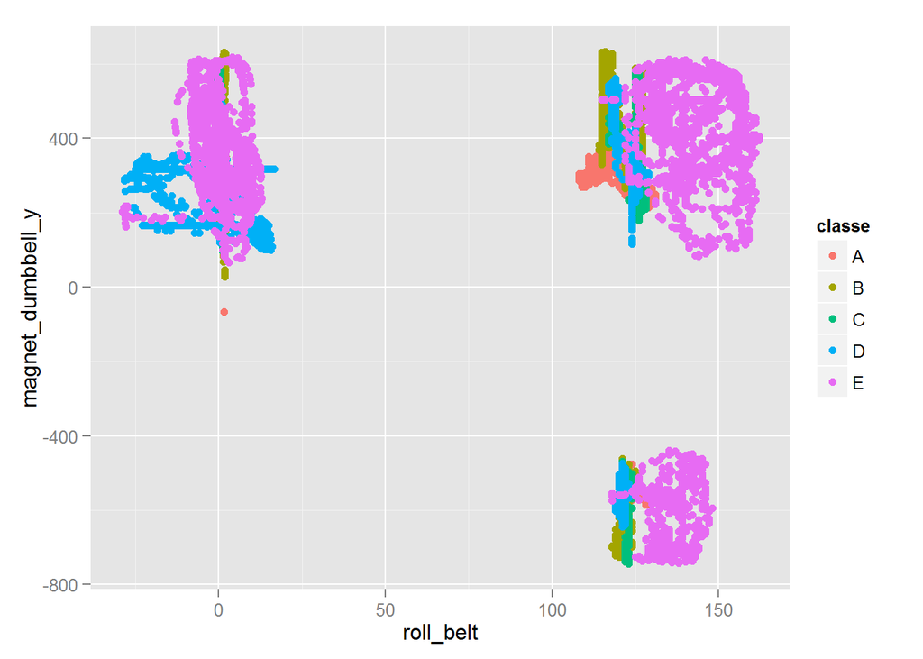

```r
library(ggplot2)
library(doParallel)
library(randomForest)
setwd("C:/Users/samsung/Documents/Data_Science/Material/Machine Learning/CourseProject")

RawData <- read.csv("pml-training.csv")
RawData[is.na(RawData)] <- 0

#removing some outliers
TrainData <- RawData[-5373,]
TrainData <- RawData[-9274,]

nsv <- nearZeroVar(TrainData, saveMetrics= TRUE)

keeps <- c("classe","roll_belt","magnet_dumbbell_y","pitch_belt","pitch_forearm","roll_forearm")
TrainData <- TrainData[keeps]

##Exploratory Charts
qplot(roll_belt, magnet_dumbbell_y, colour=classe, data=TrainData)
```

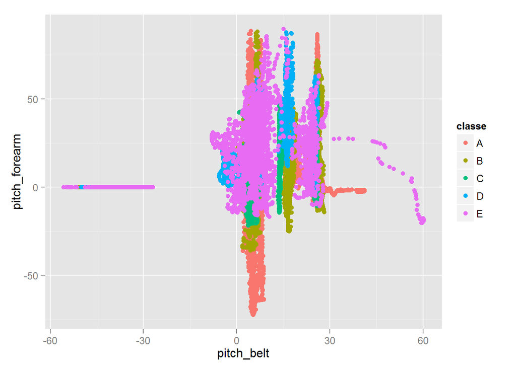

```r
qplot(pitch_belt, pitch_forearm, colour=classe, data=TrainData)
```

```r
TrainData <- TrainData[keeps]
```

I have made some exploratory charts on my own that shows how the **classes** are clustered. The five predictors are selected among the ones have variability (non-zero-variability factors) and also a considerable percentage of unique values. Not always the predictors with the highest amount of unique values are the best.

```r
set.seed(1048)

inTrain <- createDataPartition(y=TrainData$classe, p=0.60, list=FALSE)

training <- TrainData[inTrain,]
testing <- TrainData[-inTrain,]
dim(training);dim(testing)
```

```
## [1] 11775     6
```

```
## [1] 7846    6
```

```r
model <- foreach(ntree=rep(100, 4), .combine=randomForest::combine) %dopar% randomForest(training[,2:6], training$classe, ntree=ntree)
predictionsTraining <- predict(model, newdata=training)
confusionMatrix(predictionsTraining, training$classe)
```

```
## Confusion Matrix and Statistics
##
##           Reference
## Prediction    A    B    C    D    E
##          A 3293   10    0    0    0
##          B   17 2260   11    0    1
##          C   33    8 2029    7    0
##          D    5    0   14 1923    0
##          E    0    0    0    0 2164
##
## Overall Statistics
##
##                Accuracy : 0.991
##                  95% CI : (0.9891, 0.9926)
##     No Information Rate : 0.2843
##     P-Value [Acc > NIR] : < 2.2e-16
##
##                   Kappa : 0.9886
##  Mcnemar's Test P-Value : NA
##
## Statistics by Class:
##
##                      Class: A Class: B Class: C Class: D Class: E
## Sensitivity            0.9836   0.9921   0.9878   0.9964   0.9995
## Specificity            0.9988   0.9969   0.9951   0.9981   1.0000
## Pos Pred Value         0.9970   0.9873   0.9769   0.9902   1.0000
## Neg Pred Value         0.9935   0.9981   0.9974   0.9993   0.9999
## Prevalence             0.2843   0.1935   0.1744   0.1639   0.1839
## Detection Rate         0.2797   0.1919   0.1723   0.1633   0.1838
## Detection Prevalence   0.2805   0.1944   0.1764   0.1649   0.1838
## Balanced Accuracy      0.9912   0.9945   0.9914   0.9972   0.9998
```

```r
#cross-Validation
predictionsTesting <- predict(model, newdata=testing)
confusionMatrix(predictionsTesting,testing$classe)
```

```
## Confusion Matrix and Statistics
##
##           Reference
## Prediction    A    B    C    D    E
##          A 2143   24    4    0    2
##          B   32 1397   19    8   29
##          C   49   47 1319   16    9
##          D    8   34   20 1259   10
##          E    0   16    6    3 1392
##
## Overall Statistics
##
##                Accuracy : 0.9572
##                  95% CI : (0.9525, 0.9615)
##     No Information Rate : 0.2845
##     P-Value [Acc > NIR] : < 2.2e-16
##
##                   Kappa : 0.9459
##  Mcnemar's Test P-Value : 3.478e-14
##
## Statistics by Class:
##
##                      Class: A Class: B Class: C Class: D Class: E
## Sensitivity            0.9601   0.9203   0.9642   0.9790   0.9653
## Specificity            0.9947   0.9861   0.9813   0.9890   0.9961
## Pos Pred Value         0.9862   0.9407   0.9160   0.9459   0.9824
## Neg Pred Value         0.9843   0.9810   0.9924   0.9959   0.9922
## Prevalence             0.2845   0.1935   0.1744   0.1639   0.1838
## Detection Rate         0.2731   0.1781   0.1681   0.1605   0.1774
## Detection Prevalence   0.2770   0.1893   0.1835   0.1696   0.1806
## Balanced Accuracy      0.9774   0.9532   0.9728   0.9840   0.9807
```

I have made a 60% training database for training and 40% for testing (or cross-validation) given that there is a separate testing database. Both values of sensitivity and specificity are higher than 92% and the accuracy ratio is 95,72% in the cross-validation section. So the results are quite impressive.

```r
TestData <- read.csv("pml-testing.csv")

keeps2 <- c("roll_belt","magnet_dumbbell_y","pitch_belt","pitch_forearm","roll_forearm")

TestData <- TestData[keeps2]

predictionsRealTest <- predict(model, newdata=TestData)
```

The last part of the assignment tries to predict the 20 values of the final projects code.